# Sorting Algorithm Analysis

College Colloquium Final

Author

Affiliation

Isaiah Trotter

[Willamette River Valley](https://willamette.edu)

## Introduction

Scientific computing has transformed how humans work, think, and solve problems. We can automate complex, repetitive, and time-consuming tasks that can take hours or even days to complete by hand. This project shows how scientific computing makes our lives easier by taking on the tedious parts of problems.

Sorting algorithms provide a clear example of this. Sorting by hand requires focus and patience, especially with large amounts of data. Computers can execute the same logic instantly **and** without mistakes. By analyzing sorting algorithms in Python, we can see how scientific computing not only increases our efficiency but it also reduces human effort and error.

- **Thesis**: Scientific computing lets us solve problems that would be impossible to solve by hand. By testing sorting algorithms in Python, this project shows that computers don’t just work faster than humans, they help us complete goals we couldn’t do on our own. Comparing five different algorithms across different data distributions, generating graphs, and calculating statistics could take weeks of manual work. With Python, it takes minutes. This is why scientific computing matters.

### *Why* Sorting Matters

Imagine trying to find a word in a dictionary that’s in a completely random order. It would take forever; you would have to check every entry. Sorting algorithms solve this problem instantly by ordering information so it can be easily and clearly understood. Scientific computing is able to order the chaos of a dictionary using code.

Put simply, sorting is about taking something “unorganized” and making it appear “ordered”. In computer science, a sorting algorithm is the set of instructions that a computer follows to turn a jumbled list (like names, scores, or in our case, numbers) and arrange them in a specific, desired order. For this project, we will be focusing on ascending numerical order.

Now that we know sorting is important, it also becomes clear that the way we sort is important. Improving the speed of algorithms is the difference between noticeable lag and the instant display of rearranged data when working with large datasets, such as on a spreadsheet. Efficient sorting optimizes tasks like searching for data, merging datasets, finding median values, or even optimizing other algorithms that rely on sorted data. This project explores several different sorting algorithms, implemented in Python.

## Algorithm Theory

Having established why sorting matters, we now explore several algorithms that perform this task, analyzing their logic, time complexity, and implementation in Python. Each demonstrates logic that humans could perform in theory but would take far too long to do efficiently in practice.

### Selection Sort

Selection Sort is one of the most straightforward algorithms and it clearly shows how computing can automate human steps. It finds the smallest element in a list, moves it to the next position in the sorted portion, and repeats the process until everything is in order.

1. Scan the unsorted portion of the list to locate the lowest value.
2. Swap this lowest value with the element at the current starting position of the unsorted sublist.
3. Repeat the process for the remaining unsorted elements until the entire list is sorted.

#### Time Complexity

Selection Sort scans the remaining $n$ elements $n$ times, regardless of whether the list is sorted or not. Its number of comparisons stays the same for every case, resulting in a time complexity of $O(n^2)$.

- **Best Case:** $O(n^2)$
- **Average Case:** $O(n^2)$
- **Worst Case:** $O(n^2)$

#### Implementation

```python
def select_sort(in_lst):
    lst = in_lst[::]
    n = len(lst)
    for i in range(n):
        min_index = i
        for j in range(i+1, n):
            if lst[j] < lst[min_index]:
                min_index = j
        lst[i], lst[min_index] = lst[min_index], lst[i]
    return lst
```

> Modified from w3schools.com

### Insertion Sort

This algorithm builds the sorted list one element at a time. It iterates through the list, and for each element, it “inserts” it into its correct position which it assumes is to its left by shifting other elements to the right until the current element fits.

1. Start with the first element of the list, thinking of it as the initial “sorted” portion.
2. Take the next value from the unsorted portion of the list.
3. Compare this value backward against elements in the sorted portion.
4. Insert the value into the first position where it is greater than the next element.
5. Repeat until all elements are in the sorted portion.

#### Complexity

This algorithm’s performance is similar to Selection Sort. However, if the list is already sorted, it makes one pass over $n$, makes no shifts, and ends.

- **Best Case:** $O(n)$
- **Average Case:** $O(n^2)$
- **Worst Case:** $O(n^2)$

#### Implementation

```python
def insert_sort(in_lst):
    lst = in_lst[::]
    n = len(lst)
    for i in range(1,n):
        insert_index = i
        current_value = lst[i]
        for j in range(i-1, -1, -1):
            if lst[j] > current_value:
                lst[j+1] = lst[j]
                insert_index = j
            else:
                break
        lst[insert_index] = current_value
    return lst
```

> Modified from w3schools.com

### Bubble Sort

Bubble Sort is another simple, $O(n^2)$ algorithm. It repeatedly steps through the list, compares adjacent elements, and swaps them if they are in the wrong order. The largest elements “bubble” up to the end of the list with each pass.

1. Go through the list, one value at a time.
2. For each value, compare the value with the next value.
3. If the value is higher than the next one, swap the values so that the higher value moves right.
4. Go through the list as many times as there are values in the list.

#### Complexity

Bubble sort has the same time complexity as Insertion Sort. Its best-case performance is $O(n)$ if the list is already sorted.

- **Best Case:** $O(n)$
- **Average Case:** $O(n^2)$
- **Worst Case:** $O(n^2)$

#### Implementation

```python
def bubble_sort(in_lst):
    lst = in_lst[::]
    n = len(lst)
    for i in range(n-1):
        swapped = False
        for j in range(n-i-1):
            if lst[j] > lst[j+1]:
                lst[j], lst[j+1] = lst[j+1], lst[j]
                swapped = True
        if not swapped:
            break

    return lst
```

> Modified from w3schools.com

This is the simplest version for a human as it’s similar to repeatedly comparing neighbors and swapping them when out of order.

### Merge Sort

Merge Sort is a big leap in how complex and efficient the algorithm is. It splits the dataset into smaller parts, sorts each one, and then merges them together into a complete and ordered list.

1. Divide the unsorted list into two sublists, each half the size of the original.
2. Keep dividing each sublist until every piece has only one element.
3. Merge two sublists together by repeatedly placing the smallest element first.
4. Continue merging until you have combined all sublists back into a fully sorted list.

#### Complexity

Because it always divides the list, its performs the same regardless of the initial order. It takes $\log(n)$ levels of division, and each level takes $O(n)$ work to merge.

- **Best Case:** $O(n \log n)$
- **Average Case:** $O(n \log n)$
- **Worst Case:** $O(n \log n)$

#### Implementation

```python
def merge(left, right):
    result = []
    i = j = 0

    while i < len(left) and j < len(right):
        if left[i] < right[j]:
            result.append(left[i])
            i += 1
        else:
            result.append(right[j])
            j += 1

    result.extend(left[i:])
    result.extend(right[j:])

    return result

def mergeSort(in_lst):
    lst = in_lst[::]
    if len(lst) <= 1:
        return lst

    mid = len(lst) // 2
    leftHalf = lst[:mid]
    rightHalf = lst[mid:]

    sortedLeft = mergeSort(leftHalf)
    sortedRight = mergeSort(rightHalf)

    return merge(sortedLeft, sortedRight)
```

> Modified from w3schools.com

This divide and conquer method is a bit complicated for a human, and shows how computers can manage complex tasks by breaking them into smaller, simpler ones. Merge Sort is far beyond what a person could reasonably keep track of by hand.

### Python’s sorted() or Timsort

Timsort is the built-in sorting algorithm used by Python. It’s a hybrid algorithm, combining Insertion Sort and Merge Sort. It’s designed to be very fast on “real-world” data that has partially-sorted “runs”. It finds these runs, sorts them with Insertion Sort if they are small, and then merges them using Merge Sort.

#### Complexity

It is highly optimized, with a best-case of $O(n)$ and an average/worst case of $O(n \log n)$ (like Merge Sort).

- **Best Case:** $O(n)$
- **Average Case:** $O(n \log n)$
- **Worst Case:** $O(n \log n)$

#### Implementation

> We will use the built-in `sorted()` function directly in our benchmark.

## Benchmarking

Having examined the theory behind these algorithms, we will now test them using Python to verify their expected performance.

### Setup

First we need to import all of the different libraries that we are going to use for our analysis. We will also setup the lists we will be sorting.

```python
import time
import random

algorithms = [
    (select_sort, "Selection Sort"),
    (insert_sort, "Insertion Sort"),
    (bubble_sort, "Bubble Sort"),
    (mergeSort, "Merge Sort"),
    (sorted, "Timsort")
]

def grab_list(name, n):
    if name == "random_list":
        return random.sample(range(1, n+1),n)
    if name == "sorted_list":
        return list(range(1,n+1))
    if name == "reversed_list":
        return list(range(n,0,-1))
```

### Execution

The most important part of the benchmark is testing various lengths and data distributions. We measure the time taken for each algorithm to sort the different lists. Our test cases:

1. List Sizes: Ranging from 10 to 5000
2. List Types: Each size is tested on a random, sorted, and reversed list to see the difference in performance in different cases.

```python
import pandas as pd

n_values = [10, 50, 100, 250, 1000, 2500, 5000]
lsts = ["random_list", "sorted_list", "reversed_list"]
results = []

for n in n_values:
    for lst in lsts:
        current_list = grab_list(lst, n)

        for function, algorithm in algorithms:
            start_time = time.time()
            function(current_list)
            end_time = time.time()

            time_total = end_time - start_time

            results.append({
                "Algorithm": algorithm,
                "List Type": lst,
                "Size": n,
                "Time (s)": time_total
            })

df = pd.DataFrame(results)
df
```

|  | Algorithm | List Type | Size | Time (s) |
| --- | --- | --- | --- | --- |
| 0 | Selection Sort | random_list | 10 | 0.000003 |
| 1 | Insertion Sort | random_list | 10 | 0.000003 |
| 2 | Bubble Sort | random_list | 10 | 0.000003 |
| 3 | Merge Sort | random_list | 10 | 0.000008 |
| 4 | Timsort | random_list | 10 | 0.000001 |
| ... | ... | ... | ... | ... |
| 100 | Selection Sort | reversed_list | 5000 | 0.203898 |
| 101 | Insertion Sort | reversed_list | 5000 | 0.363241 |
| 102 | Bubble Sort | reversed_list | 5000 | 0.618615 |
| 103 | Merge Sort | reversed_list | 5000 | 0.003252 |
| 104 | Timsort | reversed_list | 5000 | 0.000016 |

105 rows × 4 columns

- This `DataFrame` holds all of the tests for each different type of list, list size, and the time it took for the sorting algorithm to sort the list depending on the previously mentioned factors.

### Data Table

- Now we can modify the `DataFrame` to take a look at just one category, random lists, and compare it across all algorithms by transforming the `DataFrame`.

```python
df_random = df[df["List Type"] == "random_list"]

rotate_df = df_random.pivot_table(
    index=["Algorithm"],
    columns="Size",
    values="Time (s)",
)

order = ["Selection Sort","Insertion Sort","Bubble Sort","Merge Sort","Timsort"]
rotate_df = rotate_df.reindex(order)
rotate_df.index.name = None

rotate_df
```

| Size | 10 | 50 | 100 | 250 | 1000 | 2500 | 5000 |
| --- | --- | --- | --- | --- | --- | --- | --- |
| Selection Sort | 0.000003 | 0.000021 | 0.000076 | 0.000428 | 0.008155 | 0.046646 | 0.194451 |
| Insertion Sort | 0.000003 | 0.000022 | 0.000069 | 0.000364 | 0.007134 | 0.042427 | 0.181740 |
| Bubble Sort | 0.000003 | 0.000043 | 0.000160 | 0.000925 | 0.018667 | 0.116301 | 0.487797 |
| Merge Sort | 0.000008 | 0.000027 | 0.000056 | 0.000159 | 0.000837 | 0.002295 | 0.004679 |
| Timsort | 0.000001 | 0.000002 | 0.000004 | 0.000011 | 0.000054 | 0.000147 | 0.000319 |

> Looking at this `pandas` table we can already tell a lot, like how Selection and Insertion sort are very close in values and how Merge Sort starts off slower but improves as list size increases.

### Visualization

Now in order to take a better look at all the data we write a function that when given a `list_type`, will output all of the different algorithms’ performance on that list.

```python
import matplotlib.pyplot as plt
def plot_list_type_performance(df, list_type):
    titles = {
        "random_list": "Random List",
        "sorted_list": "Sorted List",
        "reversed_list": "Reversed List"
    }

    df_plot = df[df["List Type"] == list_type]

    for algorithm in df_plot["Algorithm"].unique():
        algo_data = df_plot[df_plot["Algorithm"] == algorithm]
        plt.plot(algo_data["Size"], algo_data["Time (s)"], label=algorithm, marker='o')

    plt.legend()
    plt.xlabel("List Size")
    plt.ylabel("Time in seconds")
    plt.title(f"Algorithm Performance on {titles.get(list_type, list_type)}")
    plt.grid(True, which="both", ls="--", linewidth=0.5)
    plt.yscale('log')

    plt.show()
```

Now with this function created lets take a look at our random list.

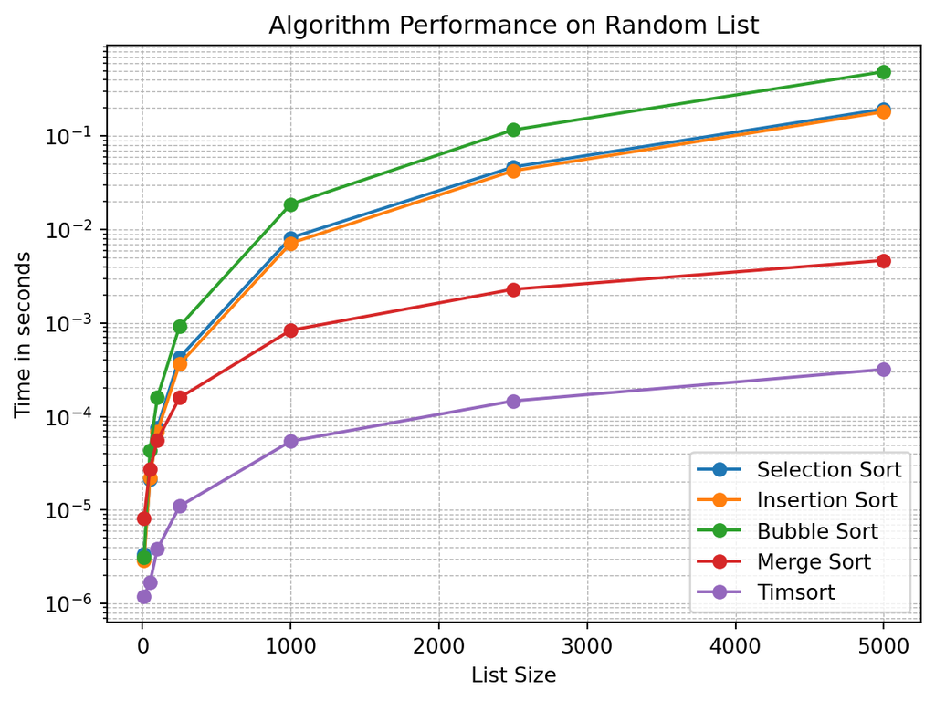

```python
plot_list_type_performance(df, "random_list")
```

> This graph represents the average scenario where the data is completely randomly generated 1 through $n$ (list size).

Looking at this graph, we can immediately tell that the superior option is in fact Timsort, as expected. We can also see a few other interesting details: Bubble Sort is noticeably worse than Selection or Insertion Sort, even though they all share the same $O(n^2)$ average-case complexity.

We can also see that Merge Sort starts out slightly slower (due to how complex it is) but as list sizes increase, it becomes significantly better than Selection, Insertion, and Bubble Sort.

Things really start to get interesting when you start to compare the different lists.

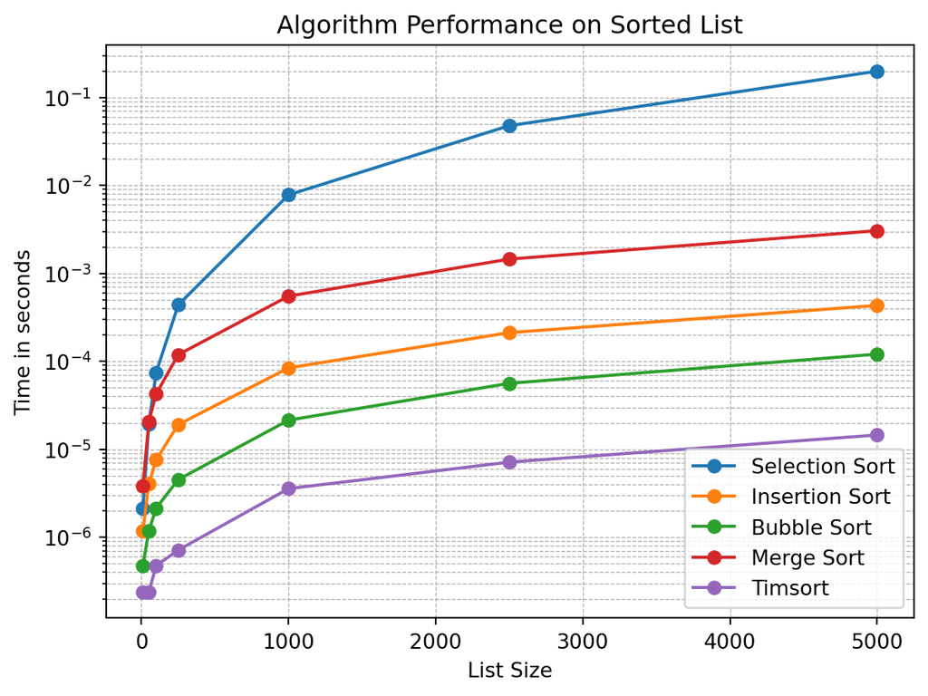

```python
plot_list_type_performance(df, "sorted_list")
```

> This graph shows each algorithm’s performance in the best-case scenario, where the list is already sorted, and the algorithm’s job is to confirm that fact.

This list reveals each algorithm on its best behavior, that being how well it can recognize that and confirm that no work is needed. Insertion and Bubble sort both perform much better in this scenario because they both include logic that checks to see if the list is already sorted. While an algorithm like Selection Sort goes through the entire list multiple times verifying that each value is already in its correct spot.

The sorted list shows us that algorithms that adapt to their given data can outperform rigid algorithms like Merge or Selection Sort. Data is rarely completely random, there are patterns in the timestamps of emails, numbers on credit cards, or even user-generated content. Algorithms that take advantage of this fact will perform the best.

We are now going to take a look at our last list type which is a reversed list from 1 to $n$.

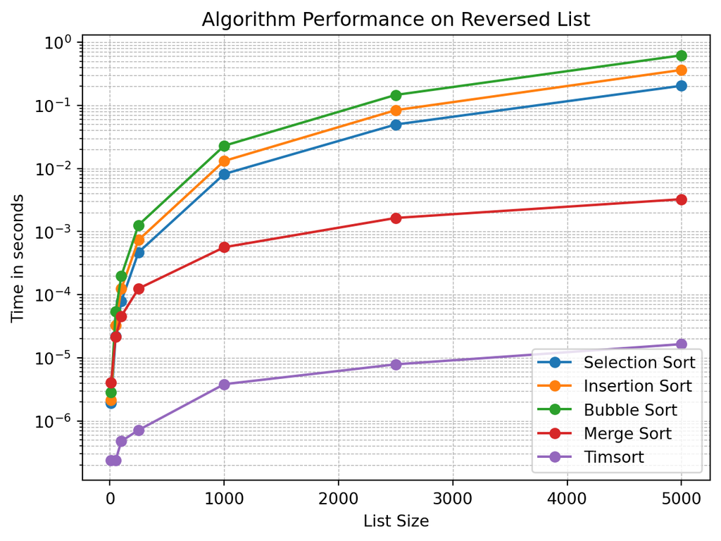

```python
plot_list_type_performance(df, "reversed_list")
```

> This graph represents the worst-case scenario where data is reversed and requires the most passes.

The reversed list shows the algorithms under maximum stress. Insertion Sort has to shift every element all the way to the beginning of the list giving us our mathematical maximum for this algorithm. The same applies to Bubble Sort where each value has to bubble through every position. On the other hand, Selection Sort it remains consistent across all variations of the lists.

By looking at these variations in lists, we are able to tell that some algorithms are better at different tasks, which is why it’s important to know the difference in performance for each algorithm.

Without these tools all of this would have taken countless hours of manual timing, data collection, and graphing. You’d also have to look at my hand drawn graphs and no one wants that. Scientific computing allows us to test, visualize, and interpret these different algorithms instantly.

## Ending Notes

### Reflections

While this project focused on analyzing sorting algorithms, there are many ways it could have been expanded to better analyze the differences. One improvement would be to increase the amount and diversity of data tested for example using larger lists, different data types, or specialized data structures in order to see how each algorithm scales under different conditions. This would give a better idea of where each different algorithm shines and where they are weak.

Currently, the timing relies on `time.time()`, which provides a quick and general result. For more precision, the `timeit` module could be used to measure average performance over many runs, reducing variance from any system “noise” or other processes. This would make the comparison more accurate.

### Real-World Impact

Scientific computing turns what was once difficult and time-consuming work into something effortless. Sorting data is used everywhere from social media feeds and search results to financial data and scientific research. Without sorting algorithms, each of these tasks would require huge amounts of manual effort and time.

Imagine trying to manually organize millions of products on Amazon or posts on social media. It would be impossible. But through algorithms like Merge Sort and Python’s built-in Timsort, computers are able to complete these tasks instantly and perfectly. This is why scientific computing is so valuable, it lets machines handle the hard work.

### Final Thoughts

Scientific computing automates the hard parts. Sorting, benchmarking, graphing, and even data comparison. In this project, scientific computing not only ran the algorithms but also generated the graphs, recorded timing data. Tasks that would have taken much longer to do by hand. It truly makes our lives easier by saving time.

## Appendix

### Bogo Sort

While looking at different sorting algorithms, it doesn’t take long to stumble upon Bogo Sort. Bogo Sort is a joke algorithm used only for educational purposes to demonstrate a terrible, inefficient approach. Its strategy is simple:

1. Check if the list is sorted.
2. If not, randomly shuffle the list.
3. Repeat.

#### Complexity

- **Best Case:** The list is already sorted. It checks once and finishes: $O(n)$.
- **Average Case:** The algorithm relies on random chance to find the *one* correct permutation out of $n!$ possible permutations. $O(n!)$.
- **Worst Case:** It could shuffle the list into the same incorrect orders forever. $\infty$.

#### Implementation

```python
def is_sorted(lst):
    n = len(lst)
    for i in range(n - 1):
        if lst[i] > lst[i + 1]:
            return False
    return True

def bogo_sort(in_lst):
    lst = in_lst[::]

    while not is_sorted(lst):
        random.shuffle(lst)

    return lst
```

> Modified from w3resource.com

This is effectively the same as taking a deck of cards, shuffling them, checking if they’re sorted and repeating the process until they are.

#### Why Bogo Sort is Absurdly Slow

We will use SymPy to write the equation that tells us how many possible combinations the lists have when using Bogo Sort. This equation will represent the math needed in order to find out how many combinations a list of size $n$ has.

```python
import sympy

n = sympy.symbols('n')
P = sympy.Function('P')
permutations = sympy.factorial(n)

eq = sympy.Eq(P(n), permutations)
print(f"$$ {sympy.latex(eq)} $$")
```

$$P{\left(n \right)} = n!$$

Now let’s calculate exactly how many possible combinations exist for different list sizes. Bogo Sort has to randomly stumble upon the **ONE** correct ordering out of all possibilities.

```python
bogo_data = []
for size in [3, 5, 7, 10, 13]:
    total = int(sympy.factorial(size))
    bogo_data.append({
        "List Size": size,
        "Permutations": f"{total:,}",
    })

df = pd.DataFrame(bogo_data)
df.index = [''] * len(df)
df
```

|  | List Size | Permutations |
| --- | --- | --- |
|  | 3 | 6 |
|  | 5 | 120 |
|  | 7 | 5,040 |
|  | 10 | 3,628,800 |
|  | 13 | 6,227,020,800 |

Taking a look at the table created above we can see that even a list of 13 items has over **6 BILLION** possible combinations. Bogo Sort could shuffle for days and still not find the correct order. This is why we excluded bogo from our benchmarks. Bogo Sort reminds us that not all answers to solving a problem are good ones.

```
This document has 3,078 words.
```